# HW3-drafting-viz

Author

Amanda Overbye

Published

February 12, 2025

# Questions & Answers

**1. Which option do you plan to pursue?**

I still plan on doing the infographic

**2. Restate your question(s). Has this changed at all since HW #1? If yes, how so?**

My question is still where is freight coming from and going and when is that happening. As I have been learning about this, I have realized there has been a freight recession that is ending now, while I think I will still keep my question general, I could see myself taking some of my data and specifying it more towards that.

**3. Explain which variables from your data set(s) you will use to answer your question(s), and how.**

The main variable is the freight variable from the freight_all data set, this is how many freight in pounds is sent with each trip. Additionally, I am using destination and origin information for my graphs.

**4. Find at least two data visualizations that you could (potentially) borrow / adapt pieces from. Link to them or download and embed them into your .qmd file, and explain which elements you might borrow (e.g. the graphic form, legend design, layout, etc.)**

[inspo2](https://substackcdn.com/image/fetch/f_auto,q_auto:good,fl_progressive:steep/https%3A%2F%2Fsubstack-post-media.s3.amazonaws.com%2Fpublic%2Fimages%2F2c38b44c-b525-4f45-9888-5efb4ff64ba0_2550x1694.png)

I like this one because it shows how to incorperate line charts and a bart chart into a graph, as that is what I am now planning on doing.

**5. Hand-draw your anticipated visualizations, then take a photo of your drawing(s) and embed it in your rendered .qmd file – note that these are not exploratory visualizations, but rather your plan for your final visualizations that you will eventually polish and submit with**

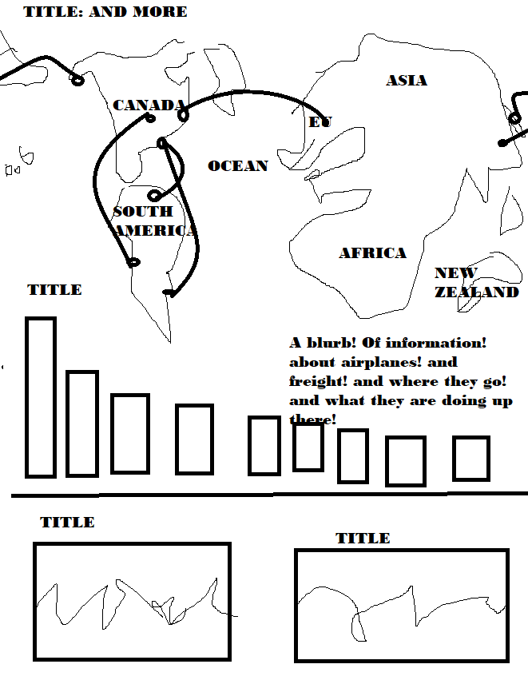

Airplanes!

**6 Mock up all of your hand drawn visualizations using code.**

See below

**7. Answer the following questions:**

1. *What challenges did you encounter or anticipate encountering as you continue to build / iterate on your visualizations in R? If you struggled with mocking up any of your three visualizations (from #6, above), describe those challenges here.*

There I am trying to figure out a way to make it all work together in one graph, then add things like typefaces and figure out text size, this is something I have yet to accomplish. Also, choosing what variables and making a map of the airports and how they connect. I originally choose the routes that were traveled the most, but then realized that I was using pounds in the timeline to connect it all, so I should probably use pounds elsewhere as well.

1. *What ggplot extension tools / packages do you need to use to build your visualizations? Are there any that we haven’t covered in class that you’ll be learning how to use for your visualizations?*
   - Airportr and geosphere are the two off the top of my head. We have used so many different packages in different classes, it is hard to remember. There is also a failed Saike chart down there, and I think there are some packages I used for that, but it was very frustrating, so I don’t really remember the packages, just the frustration.
2. *What feedback do you need from the instructional team and / or your peers to ensure that your intended message is clear?*

Please ignore the typos, I know there are a lot. I think just knowing what I should put where and the size of things. I know this document is much messier than the previous one. I am a little scared to organize it incase I throw something off with the data processing. I think aesthetics, as far as size goes. I have not messed around with the smaller aesthetics as much as I would have liked to. I really want to know what questions y’all have about this subject and what parts of it do you think are the most interesting the pull out? What questions do these plots bring to mind?

## Load necessary packages and read in your data.

```r
# Load packages
library(tidycensus)
library(tidyverse)
library(ggplot2)
library(tmap)
library(here)
library(janitor)
library(usdata)
library(tigris)
library(sf)
library(scales)
library(airportr)
library(ggmap)
library(maps)
library(patchwork)
library(lubridate)
library(gridExtra)
library(ggalluvial)
library(geosphere)
```

```r
# Testing maps
map_data_es <- map_data('world')[map_data('world')$region == "USA",]
world <- worldMapEnv
```

# Information

#### Link to data

https://www.transtats.bts.gov/DL_SelectFields.aspx?gnoyr_VQ=GDK&QO_fu146_anzr=Nv4%20Pn44vr45

https://www.transtats.bts.gov/Tables.asp?QO_VQ=EED&QO_anzr=Nv4%FDPn44vr4%FDf6n6v56vp5%FD%FLS14z%FDHE%FDg4nssvp%FM-%FD%FDh.f.%FDPn44vr45&QO_fu146_anzr=Nv4%FDPn44vr45

*More information*

https://www.transtats.bts.gov/freight.asp

*what variables mean*

Freight = Non-Stop Segment Freight Transported (pounds)

AircraftConfig: *Code Description 1 Passenger Configuration 2 Freight Configuration 3 Combined Passenger and Freight on a main deck 4 Seaplane*

### Definition of Freight

“Freight is generally understood to be merchandise or commodities that are moved by a mode of transportation, such as a truck, ship, aircraft, pipeline, or train. Freight transportation is the physical process of transporting commodities or merchandise from one place to another for a fee.” [source](https://www.fhwa.dot.gov/policy/23cpr/chap11.cfm#:~:text=Freight%20transportation%20is%20the%20physical,to%20another%20for%20a%20fee.)

```r
# Load in the data
freight2024 <- read.csv(here("data", "flights2024.csv")) %>%
  filter(FREIGHT != 0) %>%
  filter(AIRCRAFT_CONFIG == 2) %>%
  clean_names()

air_coords <- airports %>%
  clean_names()
```

```r
# Function for reading in CSVs
read <- function(year) {
  file_name <- paste0("flights", year, ".csv")
  file_path <- here("data", file_name)

  # Read and filter dataset
  df <- read.csv(file_path) %>%
    filter(FREIGHT != 0) %>%
    clean_names()

  return(df)
}
```

```r
freight2023 <- read(2023)
```

```r
freight2023 <- read(2023)
freight2022 <- read(2022)
freight2021 <- read(2021)
freight2020 <- read(2020)
freight2019 <- read(2019)
freight2018 <- read(2018)
freight2017 <- read(2017)
freight2016 <- read(2016)
freight2015 <- read(2015)
freight2014 <- read(2014)
freight2013 <- read(2013)
freight2012 <- read(2012)
freight2011 <- read(2011)
freight2010 <- read(2010)
freight2009 <- read(2009)
freight2008 <- read(2008)
freight2007 <- read(2007)
freight2006 <- read(2006)
freight2005 <- read(2005)
freight2004 <- read(2004)
```

# Join data

```r
freighttest <- full_join(freight2014, freight2015)
```

```r
# Create function to join datasets
join_freight_data <- function(...) {
  Reduce(full_join, list(...))
}

# Use the function to join all datasets
freight_all <- join_freight_data(
  freight2004, freight2005, freight2006, freight2007,
  freight2008, freight2009, freight2010, freight2011,
  freight2012, freight2013, freight2014, freight2015,
  freight2016, freight2017, freight2018, freight2019,
  freight2020, freight2021, freight2022, freight2023,
  freight2024
)
```

```r
freight_all <- freight_all %>% select(-distance_group)
```

# Data editing for the map

## Create DF with Freight_all and airport coordinates

### Sorting out the iatas

I have been planning to use the airportr package to be able to get the coordinates for each airport for the map I want to make. I realized after looking at the freight data that there were world codes but no variable for the iata. After examining the data, I learned the iatas were just the ‘origin’ and ‘dest’ columns.

```r
# Rename origin and dest columns
freight_all <- freight_all %>%
  rename(iata_origin = origin) %>%
  rename(iata_dest = dest)
```

I will also need to create columns in the air_coords data that will have the same names as the columns in the freight_all dataframe

```r
# Duplicating iata coloumn
air_coords$iata_origin = air_coords$iata

# Renaming original iata column
air_coords_rn <- air_coords %>%
  rename(iata_dest = iata)
```

### Adding coordinates to both the destination airports and the origin airports

Up until now, most of my work on dataframes with coordinates only had one set of coordinates per row, but in this case I will need there to be two. To start this process, I need to take the air_coords data and duplicate the lat-longs so that there is one for the destination, and one for the origin. I am a bit concerned here because I do not know if it matters if the lat longs are not called latitude/longitude

```r
# Duplicate and rename lat longs
air_coords_rn$lat_dest = air_coords_rn$latitude
air_coords_rn$long_dest = air_coords_rn$longitude
```

Then I will rename the original lat longs

```r
# Rename original lat longs
air_duocoords <- air_coords_rn %>%
  rename(lat_origin = latitude) %>%
  rename(long_origin = longitude)
```

### Joining the data

The first time I did this, it was with a full join which resulted in a lot of NAs, but then I used the left join and just joined the twice to ensure that the data had the coords matched for both dest and orign. To double check they were correct, I went through and manually checked a couple flights to see if they were correct and they were!

```r
# Join freight_all with air_duocoords to get destination coordinates
freight_coords <- freight_all %>%
  left_join(air_duocoords %>%
              select(iata_dest, lat_dest, long_dest),
            by = "iata_dest") %>%
  # Join again to get origin coordinates
  left_join(air_duocoords %>%
              select(iata_origin, lat_origin, long_origin),
            by = "iata_origin")
```

# Plot map graph

### Getting data for the most common routes

```r
# airport_routes <- freight_coords %>%
#   group_by(iata_origin, iata_dest) %>%
#   mutate(route_count = n()) %>%  # Create a new column with the count of routes
#   ungroup() %>%  # Remove grouping after adding the count
#   distinct(iata_origin, iata_dest, .keep_all = TRUE) %>%  # Keep only unique routes
#   arrange(desc(route_count))
```

```r
airport_routes <- freight_coords %>%
  group_by(iata_origin, iata_dest) %>%
  mutate(freight_shipped = sum(freight, na.rm = TRUE)) %>%  # Sum freight shipped for each route
  ungroup() %>%  # Remove grouping after adding the freight count
  distinct(iata_origin, iata_dest, .keep_all = TRUE) %>%  # Keep only unique routes
  arrange(desc(freight_shipped))
```

#### Get only the top 20 routes

```r
# Filtering for the top 20 routes
top_20_routes <- airport_routes %>%
  arrange(desc(freight_shipped)) %>%
  head(20)
```

### Blank world map

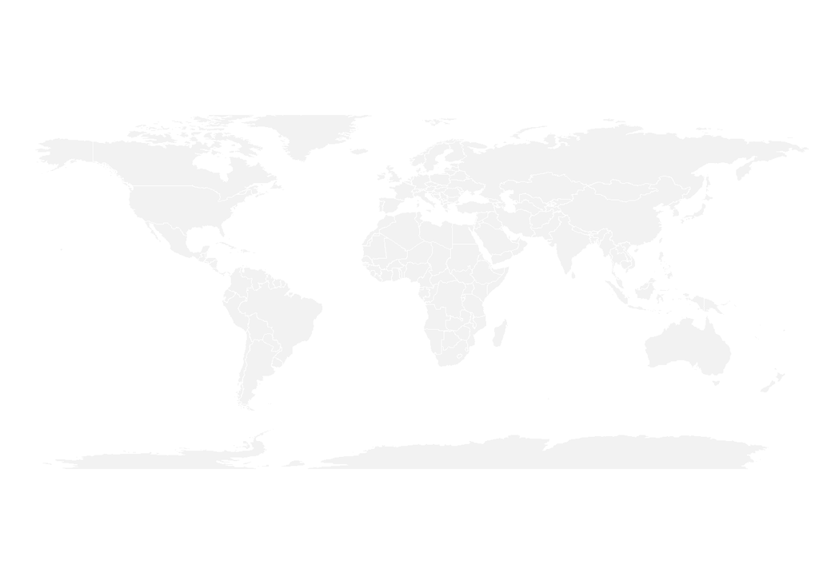

```r
# Blank world map
par(mar=c(0,0,0,0))

# World map
map('world',
    col="#f2f2f2", fill=TRUE, bg="white", lwd=0.05,
    mar=rep(0,4),border=0, ylim=c(-80,80)
)
```

### Putting points on the map

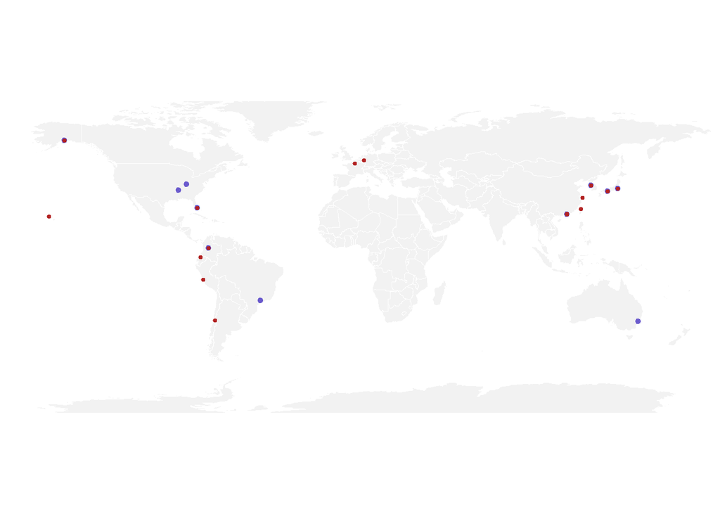

```r
# Show the cities on the map
map('world',
    col="#f2f2f2", fill=TRUE, bg="white", lwd=0.05,
    mar=rep(0,4),border=0, ylim=c(-80,80)
)
points(x=top_20_routes$long_dest, y=top_20_routes$lat_dest, col="slateblue", cex=1, pch=20)
points(x = top_20_routes$long_origin, y = top_20_routes$lat_origin, col = "firebrick", cex = 0.7, pch = 20)
```

### Making the map

```r
# Custom function to plot connections for your data
plot_my_connection <- function(dep_lon, dep_lat, arr_lon, arr_lat, ...) {

  # Get intermediate points between origin and destination
  inter <- gcIntermediate(c(dep_lon, dep_lat), c(arr_lon, arr_lat), n=50, addStartEnd=TRUE, breakAtDateLine=FALSE)
  inter <- data.frame(inter)

  # Check if the route crosses the date line (180 degrees longitude)
  diff_of_lon = abs(dep_lon) + abs(arr_lon)

  # Plot lines accordingly based on whether it crosses the date line or not
  if(diff_of_lon > 180){
    # Split the line into two parts and plot each separately
    lines(subset(inter, lon >= 0), ...)
    lines(subset(inter, lon < 0), ...)
  } else {
    # Plot the whole line as a single segment
    lines(inter, ...)
  }
}
```

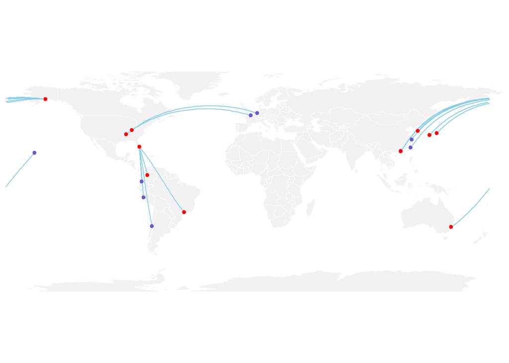

```r
# Example: Plotting the map with top_20_routes data
par(mar = c(0, 0, 0, 0))  # Set margin to zero
map('world', col = "#f2f2f2", fill = TRUE, bg = "white", lwd = 0.05, mar = rep(0, 4), border = 0, ylim = c(-80, 80))

# Plot lines connecting each pair of origin and destination
for(i in 1:nrow(top_20_routes)) {
  plot_my_connection(
    dep_lon = top_20_routes$long_origin[i],
    dep_lat = top_20_routes$lat_origin[i],
    arr_lon = top_20_routes$long_dest[i],
    arr_lat = top_20_routes$lat_dest[i],
    col = "skyblue",  # Line color
    lwd = 1  # Line width
  )
}

# Add points for origin airports
points(x = top_20_routes$long_origin, y = top_20_routes$lat_origin, col = "slateblue", cex = 1, pch = 20)

# Add points for destination airports
points(x = top_20_routes$long_dest, y = top_20_routes$lat_dest, col = "red", cex = 1, pch = 20)
```

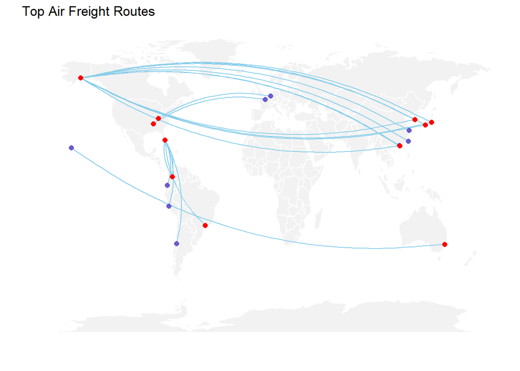

```r
# Function to create the route map
plot_routes_ggplot <- function(routes_data) {

  # Get world map data
  world_map <- map_data("world")

  # Create ggplot object
  map_pounds <- ggplot() +
    # Add world map background
    geom_polygon(data = world_map, aes(x = long, y = lat, group = group),
                 fill = "#f2f2f2", color = "white") +

    # Add curved lines for routes
    geom_curve(data = routes_data,
               aes(x = long_origin, y = lat_origin,
                   xend = long_dest, yend = lat_dest),
               curvature = 0.2, color = "skyblue", size = 0.5) +

    # Add points for origin airports
    geom_point(data = routes_data, aes(x = long_origin, y = lat_origin),
               color = "slateblue", size = 2) +

    # Add points for destination airports
    geom_point(data = routes_data, aes(x = long_dest, y = lat_dest),
               color = "red", size = 2) +

    # Theme settings
    theme_minimal() +
    theme(axis.text = element_blank(),
          axis.ticks = element_blank(),
          panel.grid = element_blank()) +
    labs(title = "Top Air Freight Routes", x = "", y = "")

  return(map_pounds)
}

# Store the plot in a variable
route_map <- plot_routes_ggplot(top_20_routes)

# Display the plot
print(route_map)
```

# Plot big time line

This plot will include information about all flights carrying freight to and from the US between 2004-2024

#### Data proccessing for big timeline

```r
# Convert year and month into a proper date format
freight_all <- freight_all %>%
  mutate(date = make_date(year, month, 1))
```

```r
# Aggregate freight by month
freight_month <- freight_all %>%
  group_by(year, month) %>%
  summarise(total_freight = sum(freight, na.rm = TRUE), .groups = "drop") %>%
  mutate(date = make_date(year, month, 1))
```

### Ploting big timeline

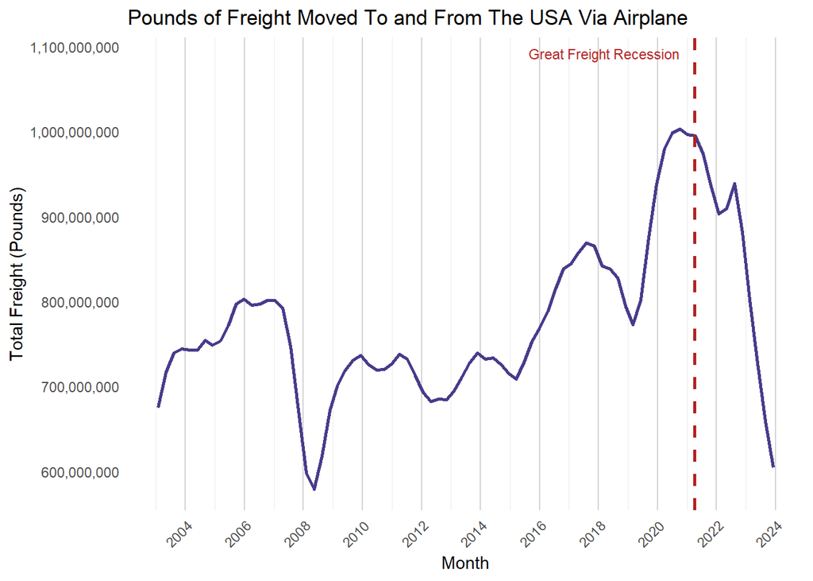

```r
# Plot monthly freight data over time
timeline <-
  ggplot(freight_month, aes(x = date, y = total_freight)) +
  geom_smooth(color = "slateblue4", size = 1, span = 0.1, se = FALSE) +
  scale_x_date(date_labels = "%Y", date_breaks = "24 months") +  # Display month and year on x-axis
  scale_y_continuous(labels = scales::comma) +
  labs(title = "Pounds of Freight Moved To and From The USA Via Airplane",
       x = "Month",
       y = "Total Freight (Pounds)") +
  theme_minimal() +
  theme(axis.text.x = element_text(angle = 45, hjust = 1),
        panel.grid.major.y = element_blank(),  # Remove horizontal grid lines
        panel.grid.minor.y = element_blank(),  # Remove minor horizontal grid lines
        panel.grid.major.x = element_line(color = "lightgray", linewidth = 0.5)) +
    annotate("text",
           x = as.Date("2022-03-01"),  # Date of annotation
           y = max(freight_month$total_freight),  # Place annotation at the top of the plot
           label = "Great Freight Recession",
           color = "firebrick",
           size = 3,
           angle = 0,
           hjust = 1.1,
           vjust = 0) +
  geom_vline(xintercept = as.Date("2022-03-01"), color = "firebrick", linetype = "dashed", size = 1)

print(timeline)
```

# Plot average year flucuations

# Organize data

```r
# Aggregate freight by month across all years
freight_avg_month <- freight_all %>%
  group_by(month) %>%
  summarise(avg_freight = mean(freight, na.rm = TRUE), .groups = "drop")
```

### Plot

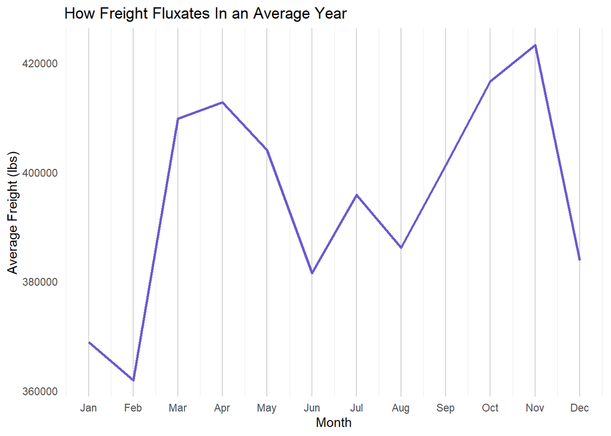

```r
# Create a line plot showing the average monthly freight
avg_year_timeline <- ggplot(freight_avg_month, aes(x = month, y = avg_freight)) +
  geom_line(color = "slateblue", size = 1) +
  #geom_point(color = "firebrick", size = 2) +  # Highlight points for each month
  scale_x_continuous(breaks = 1:12, labels = month.abb) +  # Format x-axis with month names
  labs(title = "How Freight Fluxates In an Average Year",
       x = "Month",
       y = "Average Freight (lbs)") +
  theme_minimal() +
  theme(panel.grid.major.y = element_blank(),  # Remove horizontal grid lines
        panel.grid.minor.y = element_blank(),  # Remove minor horizontal grid lines
        panel.grid.major.x = element_line(color = "lightgray", linewidth = 0.5))  # Vertical grid lines

print(avg_year_timeline)
```

## Just bars

```r
# top  10 questions
top_10 <- freight2024 %>%
  filter(!origin_country_name %in% "United States") %>%
  count(origin_country_name, sort = TRUE) %>%
  slice_max(n, n = 10) %>%
  arrange(desc(n))
```

### Plot Countries

```r
country_plot <- ggplot(top_10, aes(x = fct_reorder(origin_country_name,desc(n)),
                   y = n,
                   fill = origin_country_name)) +
  geom_col() +
  theme_void()  +
  theme(legend.position = "none")
```

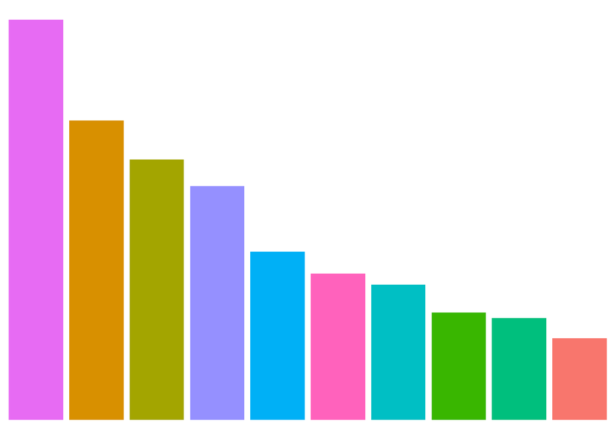

```r
print(country_plot)
```

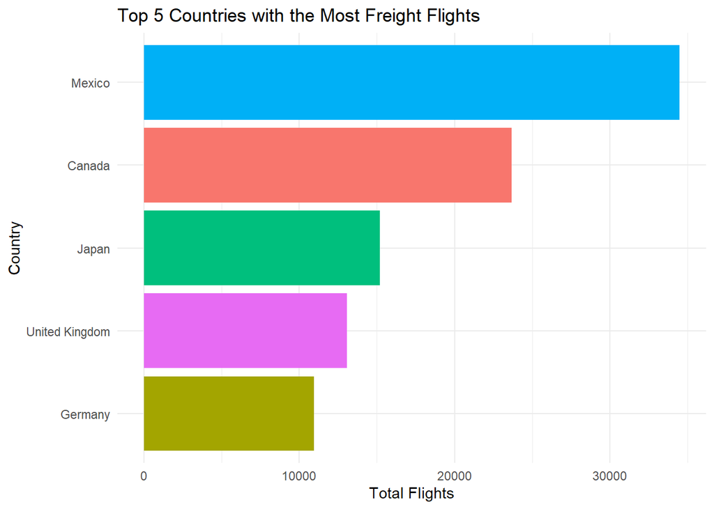

```r
top_5_countries <- freight_all %>%
  filter(!origin_country_name %in% "United States") %>%
  count(origin_country_name, sort = TRUE) %>%
  slice_max(n, n = 5)

country_bar <- ggplot(top_5_countries, aes(x = reorder(origin_country_name, n), y = n, fill = origin_country_name)) +
  geom_col(show.legend = FALSE) +
  coord_flip() +
  labs(
    title = "Top 5 Countries with the Most Freight Flights",
    x = "Country",
    y = "Total Flights"
  ) +
  theme_minimal()

print(country_bar)
```

# Saike Chart

### Editing data for chart

I like to think of it as bar prison and saike hell

```r
# Find the top 5 cities with the most departures
top_cities <- freight_all %>%
  group_by(origin_city_name) %>%
  summarise(total_flights = n()) %>%
  arrange(desc(total_flights)) %>%
  slice(1:5)

# Filter the dataset to only include flights from these top cities
freight_top <- freight_all %>%
  filter(origin_city_name %in% top_cities$origin_city_name) %>%
  group_by(origin_city_name, dest_city_name) %>%
  summarise(total_flights = n(), .groups = "drop")
```

### Data stuff attempt 2

```r
# Find the top 5 origin countries with the most flights
top_origin_countries <- freight_all %>%
  group_by(origin_country_name) %>%
  summarise(total_flights = n()) %>%
  arrange(desc(total_flights)) %>%
  slice(1:5)  # Select top 5 origin countries

# Find the top 5 destination countries with the most flights
top_dest_countries <- freight_all %>%
  group_by(dest_country_name) %>%
  summarise(total_flights = n()) %>%
  arrange(desc(total_flights)) %>%
  slice(1:5)  # Select top 5 destination countries

# Filter the dataset to include flights between the top origin and top destination countries
freight_top <- freight_all %>%
  filter(origin_country_name %in% top_origin_countries$origin_country_name &
         dest_country_name %in% top_dest_countries$dest_country_name) %>%
  group_by(origin_country_name, dest_country_name) %>%
  summarise(total_flights = n(), .groups = "drop")
```

### Create Plot

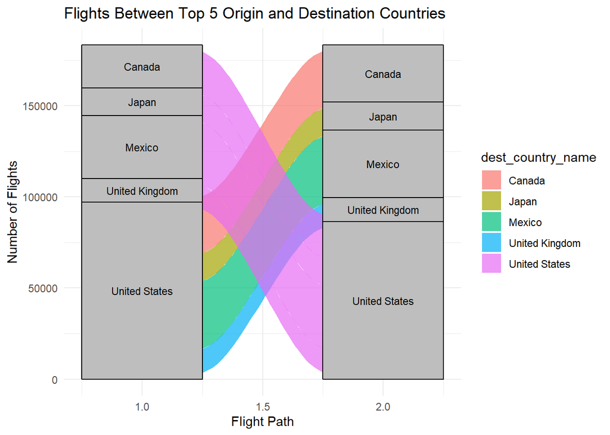

```r
ggplot(freight_top,
       aes(axis1 = origin_country_name, axis2 = dest_country_name, y = total_flights)) +
  geom_alluvium(aes(fill = dest_country_name), width = 0.3, alpha = 0.7) +
  geom_stratum(width = 0.5, fill = "grey") +
  geom_text(stat = "stratum", aes(label = after_stat(stratum)), size = 3) +
  labs(title = "Flights Between Top 5 Origin and Destination Countries",
       x = "Flight Path",
       y = "Number of Flights") +
  theme_minimal()
```

# Create it again

[figure not shown]

```r
ggplot(freight_top,
       aes(axis1 = origin_country_name, axis2 = dest_country_name, y = total_flights)) +
  geom_alluvium(aes(fill = dest_country_name), width = 0.3, alpha = 0.7) +
  geom_stratum(width = 0.5, fill = "grey") +
  geom_text(stat = "stratum", aes(label = after_stat(stratum)), size = 3) +
  labs(title = "Flights from the United States to Top 5 Destination Countries",
       x = "Flight Path",
       y = "Number of Flights") +
  theme_minimal()
```

# Mock up of hand drawn visualizations using code

#### Goal:

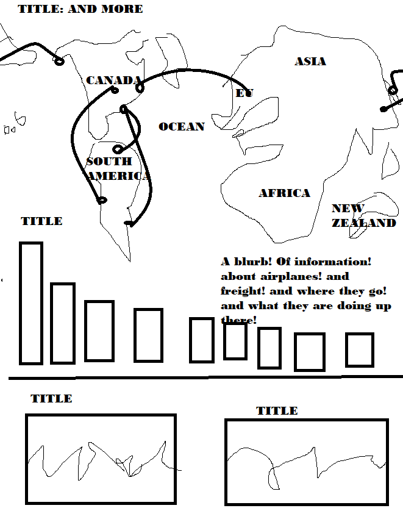

Airplanes!

## Create base plot

I didnt actually use this one :(

```r
plot_base <- ggplot() +

  # Add labels, subtitles, and caption to plot
  labs(
    title = "Airplanes & Freight",
    subtitle = "Airplanes carry a lot of freight different places",
    caption = "they can flY!"
    ) +

  # apply a completely empty theme ----
  theme_void() +

  # further customize theme ----
  theme(

   # Set preferences for text including font and size
    text = element_text(size = 16,
                        lineheight = 0.3,
                        color = "black"),

    # Fill in the background with color

    # make plot background black
    plot.background = element_rect(fill = "lightblue1",
                                   color = "lightblue1"),

    # Plot the title and add text preferences
    plot.title = element_text(size = 42,
                              face = "bold",
                              hjust = 0.5,
                              margin = margin(b = 10)),

    # Plot subtitle and add text preferences
    plot.subtitle = element_text(hjust = 0.5,
                                 margin = margin(b = 20)),

    # format plot caption using {ggtext} to render fontawesome icons ----
    plot.caption = ggtext::element_markdown(face = "italic",
                                            color = "white",
                                            hjust = 0.5,
                                            margin = margin(t = 20)),

    # Add margins and space to the plot
    plot.margin = margin(b = 20, t = 50, r = 50, l = 50)

  )
```

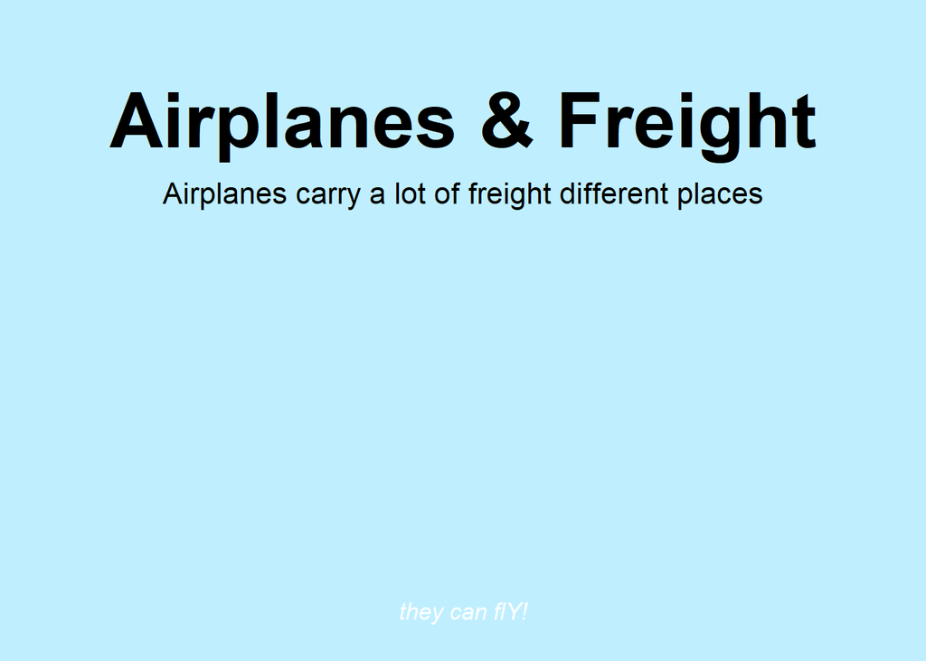

```r
plot_base
```

```r
plot_base2 <- ggplot() +

  # Add labels, subtitles, and caption to plot
  labs(
    title = "Airplanes & Freight",
    subtitle = "Airplanes carry a lot of freight different places",
    caption = "they can flY!"
    ) +

  # apply a completely empty theme ----
  theme_void()
```

# Add elements together!

```r
# Add them all together
plot_final2 <- plot_base2 +

  inset_element(route_map, left = 0.1, right = 0.9, top = 1, bottom = 0.55) +
  inset_element(avg_year_timeline, left = 0.1, right = 0.45, top = 0.5, bottom = 0.28) +
  inset_element(timeline, left = 0.1, right = 0.45, top = 0.28, bottom = 0.05) +
  inset_element(country_bar, left = 0.5, right = 0.9, top = 0.5, bottom = 0.05)
```

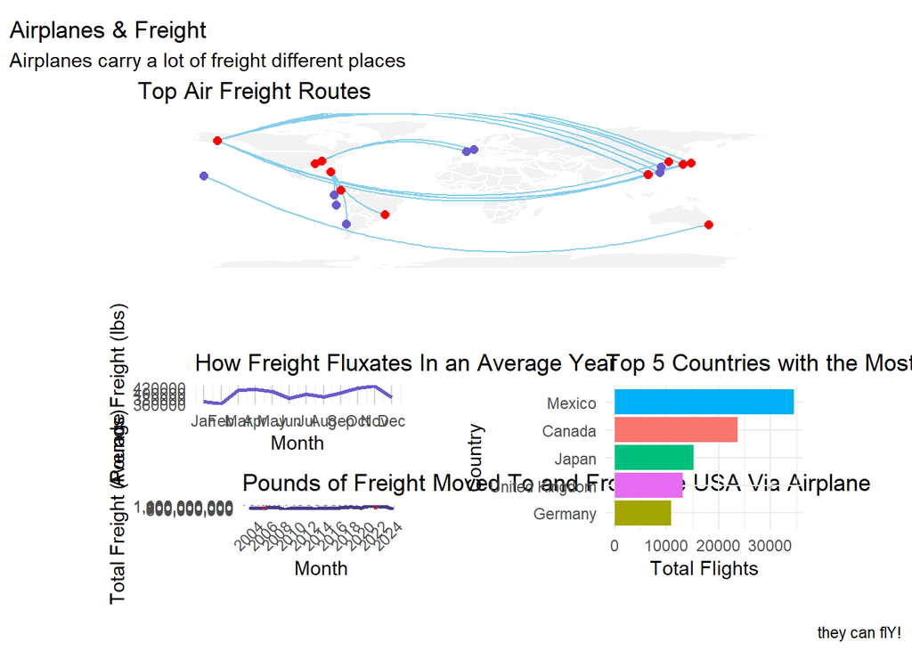

```r
plot_final2
```

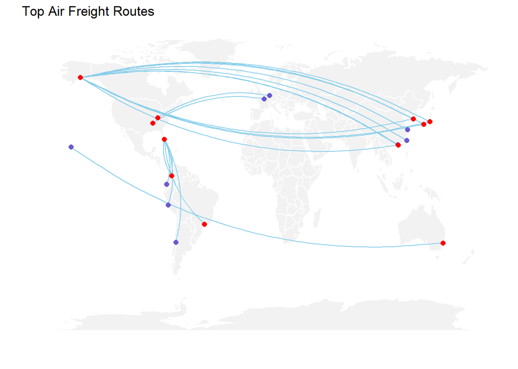

```r
route_map
```

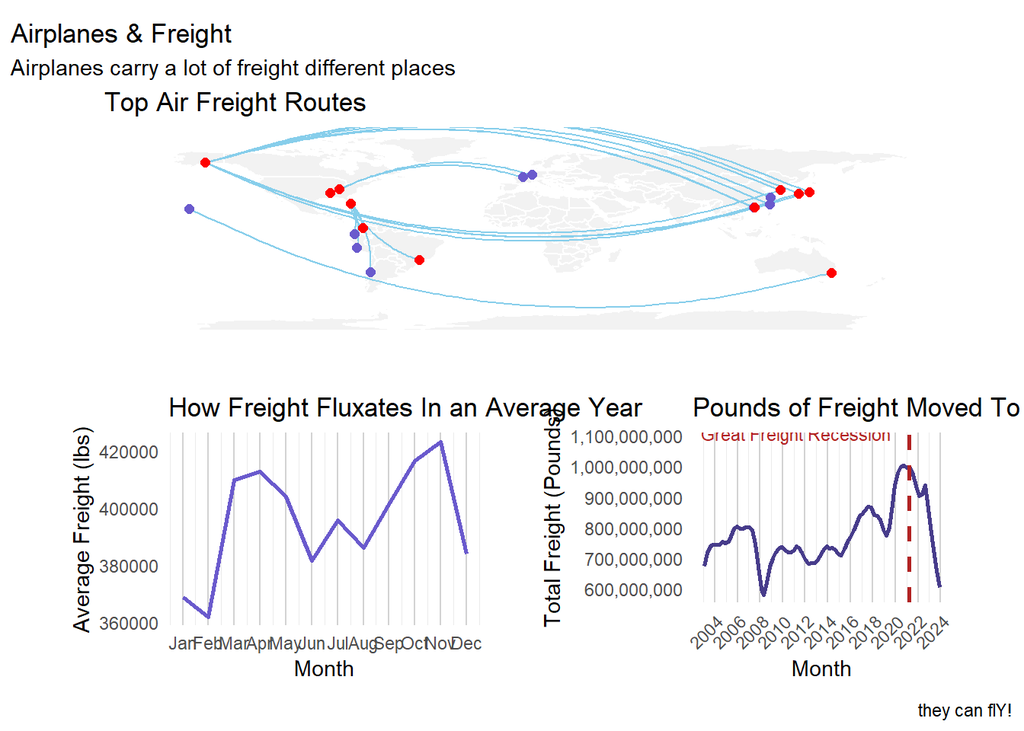

```r
plot_final3 <- plot_base2 +

  # Map takes the top half
  inset_element(route_map, left = 0.05, right = 0.95, top = 1, bottom = 0.5) +

  # Timeline plots side by side on the bottom
  inset_element(avg_year_timeline, left = 0.05, right = 0.48, top = 0.5, bottom = 0) +
  inset_element(timeline, left = 0.52, right = 0.95, top = 0.5, bottom = 0)


print(plot_final3)
```

# Using merge to look at timelines together

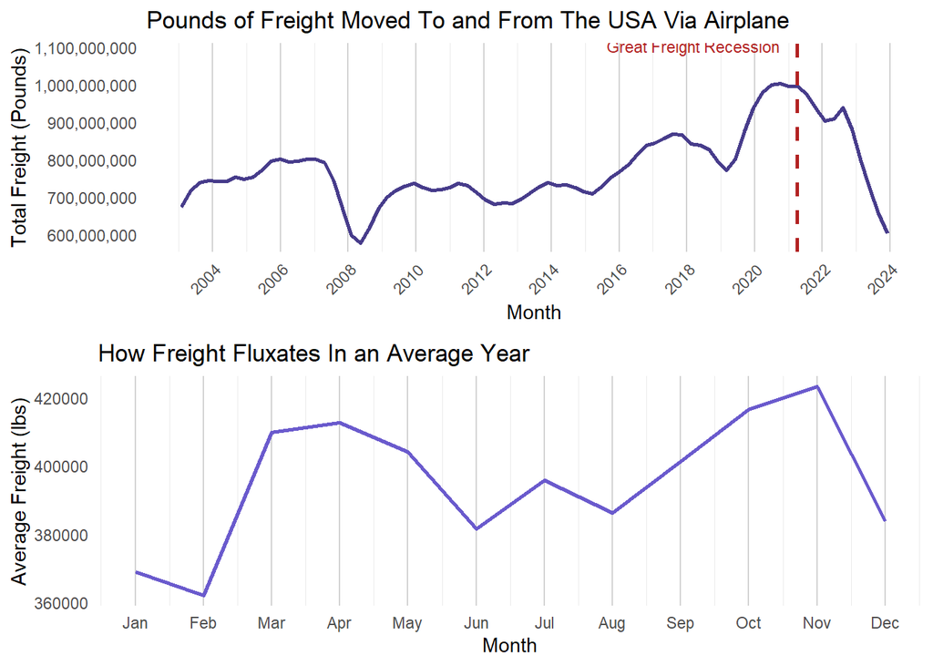

```r
grid.arrange(timeline, avg_year_timeline, ncol = 1)
```